# Risk Factor Analysis

## Outcome Variable

**Outcome Variable:** haz

## Predictor Variables

**Intervention Variable:** nhh

**Adjustment Set:**

- arm
- W_mage
- meducyrs
- feducyrs
- hhwealth_quart
- W_mhtcm
- W_mwtkg
- W_mbmi
- W_nrooms
- cleanck
- impfloor
- impsan
- safeh20
- delta_W_mage
- delta_meducyrs
- delta_feducyrs
- delta_hhwealth_quart
- delta_W_mhtcm
- delta_W_mwtkg
- delta_W_mbmi
- delta_W_nrooms
- delta_cleanck
- delta_impfloor
- delta_impsan
- delta_safeh20

## Stratifying Variables

The analysis was stratified on these variable(s):

- agecat
- studyid
- country

## Data Summary

| agecat | studyid | country | nhh | n_cell | n | outcome_variable |
| --- | --- | --- | --- | --- | --- | --- |
| Birth | IRC | INDIA | 3 or less | 54 | 388 | haz |
| Birth | IRC | INDIA | 4-5 | 150 | 388 | haz |
| Birth | IRC | INDIA | 6-7 | 103 | 388 | haz |
| Birth | IRC | INDIA | 8+ | 81 | 388 | haz |
| Birth | NIH-Birth | BANGLADESH | 3 or less | 112 | 608 | haz |
| Birth | NIH-Birth | BANGLADESH | 4-5 | 255 | 608 | haz |
| Birth | NIH-Birth | BANGLADESH | 6-7 | 138 | 608 | haz |
| Birth | NIH-Birth | BANGLADESH | 8+ | 103 | 608 | haz |
| Birth | NIH-Crypto | BANGLADESH | 3 or less | 108 | 732 | haz |
| Birth | NIH-Crypto | BANGLADESH | 4-5 | 328 | 732 | haz |
| Birth | NIH-Crypto | BANGLADESH | 6-7 | 176 | 732 | haz |
| Birth | NIH-Crypto | BANGLADESH | 8+ | 120 | 732 | haz |
| Birth | PROVIDE | BANGLADESH | 3 or less | 104 | 539 | haz |
| Birth | PROVIDE | BANGLADESH | 4-5 | 251 | 539 | haz |
| Birth | PROVIDE | BANGLADESH | 6-7 | 116 | 539 | haz |
| Birth | PROVIDE | BANGLADESH | 8+ | 68 | 539 | haz |
| 6 months | IRC | INDIA | 3 or less | 58 | 407 | haz |
| 6 months | IRC | INDIA | 4-5 | 158 | 407 | haz |
| 6 months | IRC | INDIA | 6-7 | 106 | 407 | haz |
| 6 months | IRC | INDIA | 8+ | 85 | 407 | haz |
| 6 months | LCNI-5 | MALAWI | 3 or less | 224 | 816 | haz |
| 6 months | LCNI-5 | MALAWI | 4-5 | 340 | 816 | haz |
| 6 months | LCNI-5 | MALAWI | 6-7 | 182 | 816 | haz |
| 6 months | LCNI-5 | MALAWI | 8+ | 70 | 816 | haz |
| 6 months | NIH-Birth | BANGLADESH | 3 or less | 95 | 537 | haz |
| 6 months | NIH-Birth | BANGLADESH | 4-5 | 227 | 537 | haz |
| 6 months | NIH-Birth | BANGLADESH | 6-7 | 128 | 537 | haz |
| 6 months | NIH-Birth | BANGLADESH | 8+ | 87 | 537 | haz |
| 6 months | NIH-Crypto | BANGLADESH | 3 or less | 104 | 715 | haz |
| 6 months | NIH-Crypto | BANGLADESH | 4-5 | 326 | 715 | haz |
| 6 months | NIH-Crypto | BANGLADESH | 6-7 | 170 | 715 | haz |
| 6 months | NIH-Crypto | BANGLADESH | 8+ | 115 | 715 | haz |
| 6 months | PROVIDE | BANGLADESH | 3 or less | 105 | 604 | haz |
| 6 months | PROVIDE | BANGLADESH | 4-5 | 289 | 604 | haz |
| 6 months | PROVIDE | BANGLADESH | 6-7 | 130 | 604 | haz |
| 6 months | PROVIDE | BANGLADESH | 8+ | 80 | 604 | haz |
| 6 months | SAS-FoodSuppl | INDIA | 3 or less | 33 | 380 | haz |
| 6 months | SAS-FoodSuppl | INDIA | 4-5 | 166 | 380 | haz |
| 6 months | SAS-FoodSuppl | INDIA | 6-7 | 115 | 380 | haz |
| 6 months | SAS-FoodSuppl | INDIA | 8+ | 66 | 380 | haz |
| 24 months | IRC | INDIA | 3 or less | 58 | 409 | haz |
| 24 months | IRC | INDIA | 4-5 | 158 | 409 | haz |
| 24 months | IRC | INDIA | 6-7 | 107 | 409 | haz |
| 24 months | IRC | INDIA | 8+ | 86 | 409 | haz |
| 24 months | LCNI-5 | MALAWI | 3 or less | 159 | 574 | haz |
| 24 months | LCNI-5 | MALAWI | 4-5 | 237 | 574 | haz |
| 24 months | LCNI-5 | MALAWI | 6-7 | 129 | 574 | haz |
| 24 months | LCNI-5 | MALAWI | 8+ | 49 | 574 | haz |
| 24 months | NIH-Birth | BANGLADESH | 3 or less | 75 | 429 | haz |
| 24 months | NIH-Birth | BANGLADESH | 4-5 | 184 | 429 | haz |
| 24 months | NIH-Birth | BANGLADESH | 6-7 | 100 | 429 | haz |
| 24 months | NIH-Birth | BANGLADESH | 8+ | 70 | 429 | haz |
| 24 months | NIH-Crypto | BANGLADESH | 3 or less | 69 | 514 | haz |
| 24 months | NIH-Crypto | BANGLADESH | 4-5 | 232 | 514 | haz |
| 24 months | NIH-Crypto | BANGLADESH | 6-7 | 130 | 514 | haz |
| 24 months | NIH-Crypto | BANGLADESH | 8+ | 83 | 514 | haz |
| 24 months | PROVIDE | BANGLADESH | 3 or less | 106 | 578 | haz |
| 24 months | PROVIDE | BANGLADESH | 4-5 | 273 | 578 | haz |
| 24 months | PROVIDE | BANGLADESH | 6-7 | 117 | 578 | haz |
| 24 months | PROVIDE | BANGLADESH | 8+ | 82 | 578 | haz |

The following strata were considered:

- agecat: 24 months, studyid: IRC, country: INDIA
- agecat: 24 months, studyid: LCNI-5, country: MALAWI
- agecat: 24 months, studyid: NIH-Birth, country: BANGLADESH
- agecat: 24 months, studyid: NIH-Crypto, country: BANGLADESH
- agecat: 24 months, studyid: PROVIDE, country: BANGLADESH
- agecat: 6 months, studyid: IRC, country: INDIA
- agecat: 6 months, studyid: LCNI-5, country: MALAWI
- agecat: 6 months, studyid: NIH-Birth, country: BANGLADESH
- agecat: 6 months, studyid: NIH-Crypto, country: BANGLADESH
- agecat: 6 months, studyid: PROVIDE, country: BANGLADESH
- agecat: 6 months, studyid: SAS-FoodSuppl, country: INDIA
- agecat: Birth, studyid: IRC, country: INDIA
- agecat: Birth, studyid: NIH-Birth, country: BANGLADESH
- agecat: Birth, studyid: NIH-Crypto, country: BANGLADESH
- agecat: Birth, studyid: PROVIDE, country: BANGLADESH

## Methods Detail

We’re interested in the causal parameters $E[Y_a]$ for all values of $a \in \mathcal{A}$. These parameters represent the mean outcome if, possibly contrary to fact, we intervened to set all units to have $A=a$. Under the randomization and positivity assumptions, these are identified by the statistical parameters $\psi_a=E_W[E_{Y|A,W}(Y|A=a,W)]$. In addition, we’re interested in the mean of $Y$, $E[Y]$ under no intervention (the observed mean). We will estimate these parameters by using SuperLearner to fit the relevant likelihood factors – $E_{Y|A,W}(Y|A=a,W)$ and $p(A=a|W)$, and then updating our likelihood fit using a joint TMLE.

For unadjusted analyses ($W=\{\}$), initial likelihoods were estimated using Lrnr_glm to estimate the simple $E(Y|A)$ and Lrnr_mean to estimate $p(A)$. For adjusted analyses, a small library containing Lrnr_glmnet, Lrnr_xgboost, and Lrnr_mean was used.

Having estimated these parameters, we will then use the delta method to estimate relative risks and attributable risks relative to a prespecified baseline level of $A$.

# Results Detail

## Results Plots

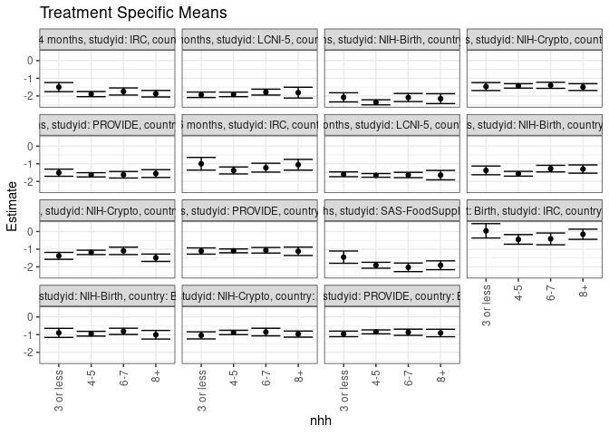

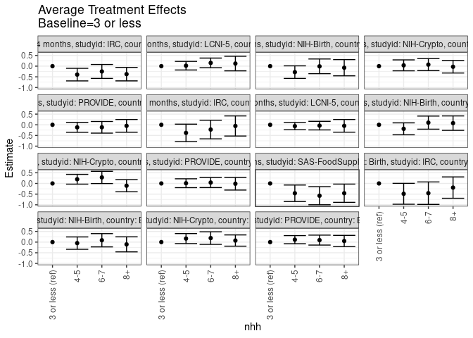

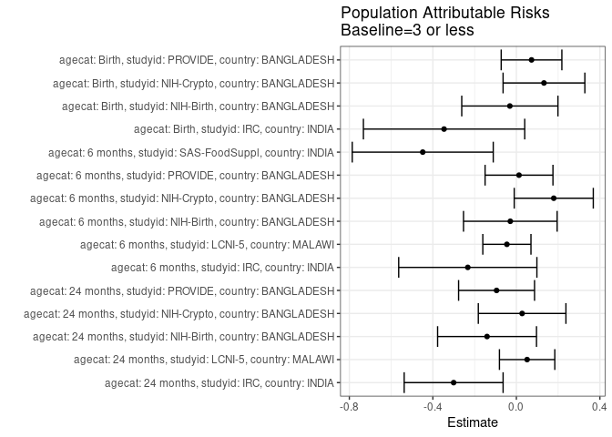

## Results Table

### Parameter: TSM

| agecat | studyid | country | intervention_level | baseline_level | estimate | ci_lower | ci_upper |
| --- | --- | --- | --- | --- | --- | --- | --- |
| Birth | IRC | INDIA | 3 or less | NA | 0.0382908 | -0.3689384 | 0.4455200 |
| Birth | IRC | INDIA | 4-5 | NA | -0.4466575 | -0.7182916 | -0.1750234 |
| Birth | IRC | INDIA | 6-7 | NA | -0.4176356 | -0.7503857 | -0.0848856 |
| Birth | IRC | INDIA | 8+ | NA | -0.1565937 | -0.4445068 | 0.1313193 |
| Birth | NIH-Birth | BANGLADESH | 3 or less | NA | -0.8997940 | -1.1566108 | -0.6429773 |
| Birth | NIH-Birth | BANGLADESH | 4-5 | NA | -0.9476135 | -1.0827600 | -0.8124669 |
| Birth | NIH-Birth | BANGLADESH | 6-7 | NA | -0.8133367 | -0.9902771 | -0.6363963 |
| Birth | NIH-Birth | BANGLADESH | 8+ | NA | -1.0064614 | -1.2490314 | -0.7638913 |
| Birth | NIH-Crypto | BANGLADESH | 3 or less | NA | -1.0416737 | -1.2422172 | -0.8411301 |
| Birth | NIH-Crypto | BANGLADESH | 4-5 | NA | -0.8765687 | -0.9982628 | -0.7548746 |
| Birth | NIH-Crypto | BANGLADESH | 6-7 | NA | -0.8537446 | -1.0691357 | -0.6383536 |
| Birth | NIH-Crypto | BANGLADESH | 8+ | NA | -0.9692655 | -1.1412322 | -0.7972987 |
| Birth | PROVIDE | BANGLADESH | 3 or less | NA | -0.9577151 | -1.1150316 | -0.8003985 |
| Birth | PROVIDE | BANGLADESH | 4-5 | NA | -0.8439698 | -0.9541850 | -0.7337546 |
| Birth | PROVIDE | BANGLADESH | 6-7 | NA | -0.8647732 | -1.0395910 | -0.6899554 |
| Birth | PROVIDE | BANGLADESH | 8+ | NA | -0.9071293 | -1.1194463 | -0.6948124 |
| 6 months | IRC | INDIA | 3 or less | NA | -1.0017675 | -1.3598801 | -0.6436550 |
| 6 months | IRC | INDIA | 4-5 | NA | -1.3812264 | -1.5791027 | -1.1833502 |
| 6 months | IRC | INDIA | 6-7 | NA | -1.2242678 | -1.4732060 | -0.9753295 |
| 6 months | IRC | INDIA | 8+ | NA | -1.0566794 | -1.3619706 | -0.7513883 |
| 6 months | LCNI-5 | MALAWI | 3 or less | NA | -1.5972920 | -1.7329056 | -1.4616783 |
| 6 months | LCNI-5 | MALAWI | 4-5 | NA | -1.6594950 | -1.7635943 | -1.5553958 |
| 6 months | LCNI-5 | MALAWI | 6-7 | NA | -1.6360723 | -1.7871962 | -1.4849484 |
| 6 months | LCNI-5 | MALAWI | 8+ | NA | -1.6457208 | -1.9122230 | -1.3792187 |
| 6 months | NIH-Birth | BANGLADESH | 3 or less | NA | -1.3784028 | -1.6243008 | -1.1325048 |
| 6 months | NIH-Birth | BANGLADESH | 4-5 | NA | -1.5672309 | -1.7015414 | -1.4329203 |
| 6 months | NIH-Birth | BANGLADESH | 6-7 | NA | -1.2763006 | -1.4612601 | -1.0913411 |
| 6 months | NIH-Birth | BANGLADESH | 8+ | NA | -1.3005194 | -1.5329838 | -1.0680551 |
| 6 months | NIH-Crypto | BANGLADESH | 3 or less | NA | -1.3777538 | -1.5728371 | -1.1826705 |
| 6 months | NIH-Crypto | BANGLADESH | 4-5 | NA | -1.1813568 | -1.3041749 | -1.0585386 |
| 6 months | NIH-Crypto | BANGLADESH | 6-7 | NA | -1.0951599 | -1.3045730 | -0.8857468 |
| 6 months | NIH-Crypto | BANGLADESH | 8+ | NA | -1.4848365 | -1.6930544 | -1.2766185 |
| 6 months | PROVIDE | BANGLADESH | 3 or less | NA | -1.1043769 | -1.2803333 | -0.9284204 |
| 6 months | PROVIDE | BANGLADESH | 4-5 | NA | -1.0942610 | -1.2037861 | -0.9847358 |
| 6 months | PROVIDE | BANGLADESH | 6-7 | NA | -1.0621679 | -1.2197645 | -0.9045714 |
| 6 months | PROVIDE | BANGLADESH | 8+ | NA | -1.1187657 | -1.3555925 | -0.8819390 |
| 6 months | SAS-FoodSuppl | INDIA | 3 or less | NA | -1.4502456 | -1.7975796 | -1.1029116 |
| 6 months | SAS-FoodSuppl | INDIA | 4-5 | NA | -1.9097727 | -2.0781080 | -1.7414374 |
| 6 months | SAS-FoodSuppl | INDIA | 6-7 | NA | -2.0262263 | -2.2684066 | -1.7840460 |
| 6 months | SAS-FoodSuppl | INDIA | 8+ | NA | -1.9093417 | -2.1590473 | -1.6596362 |
| 24 months | IRC | INDIA | 3 or less | NA | -1.4983141 | -1.7549002 | -1.2417280 |
| 24 months | IRC | INDIA | 4-5 | NA | -1.8950682 | -2.0406509 | -1.7494855 |
| 24 months | IRC | INDIA | 6-7 | NA | -1.7470915 | -1.9490425 | -1.5451406 |
| 24 months | IRC | INDIA | 8+ | NA | -1.8729169 | -2.0572126 | -1.6886211 |
| 24 months | LCNI-5 | MALAWI | 3 or less | NA | -1.9337622 | -2.0879925 | -1.7795320 |
| 24 months | LCNI-5 | MALAWI | 4-5 | NA | -1.9122552 | -2.0421268 | -1.7823835 |
| 24 months | LCNI-5 | MALAWI | 6-7 | NA | -1.7822134 | -1.9478314 | -1.6165954 |
| 24 months | LCNI-5 | MALAWI | 8+ | NA | -1.8120138 | -2.1175419 | -1.5064857 |
| 24 months | NIH-Birth | BANGLADESH | 3 or less | NA | -2.0786392 | -2.3369736 | -1.8203047 |
| 24 months | NIH-Birth | BANGLADESH | 4-5 | NA | -2.3596857 | -2.5040567 | -2.2153146 |
| 24 months | NIH-Birth | BANGLADESH | 6-7 | NA | -2.0874962 | -2.3157195 | -1.8592729 |
| 24 months | NIH-Birth | BANGLADESH | 8+ | NA | -2.1523333 | -2.4320650 | -1.8726015 |
| 24 months | NIH-Crypto | BANGLADESH | 3 or less | NA | -1.4688214 | -1.6935458 | -1.2440970 |
| 24 months | NIH-Crypto | BANGLADESH | 4-5 | NA | -1.4309072 | -1.5568323 | -1.3049820 |
| 24 months | NIH-Crypto | BANGLADESH | 6-7 | NA | -1.3975568 | -1.5707509 | -1.2243626 |
| 24 months | NIH-Crypto | BANGLADESH | 8+ | NA | -1.4970031 | -1.6890336 | -1.3049725 |
| 24 months | PROVIDE | BANGLADESH | 3 or less | NA | -1.5075636 | -1.7101248 | -1.3050025 |
| 24 months | PROVIDE | BANGLADESH | 4-5 | NA | -1.6274273 | -1.7472014 | -1.5076532 |
| 24 months | PROVIDE | BANGLADESH | 6-7 | NA | -1.6243562 | -1.8089079 | -1.4398046 |
| 24 months | PROVIDE | BANGLADESH | 8+ | NA | -1.5570665 | -1.7775099 | -1.3366232 |

### Parameter: E(Y)

| agecat | studyid | country | intervention_level | baseline_level | estimate | ci_lower | ci_upper |
| --- | --- | --- | --- | --- | --- | --- | --- |
| Birth | IRC | INDIA | NA | NA | -0.3080412 | -0.4687931 | -0.1472894 |
| Birth | NIH-Birth | BANGLADESH | NA | NA | -0.9310197 | -1.0197391 | -0.8423003 |
| Birth | NIH-Crypto | BANGLADESH | NA | NA | -0.9094945 | -0.9809370 | -0.8380521 |
| Birth | PROVIDE | BANGLADESH | NA | NA | -0.8851020 | -0.9601332 | -0.8100709 |
| 6 months | IRC | INDIA | NA | NA | -1.2344062 | -1.3658524 | -1.1029600 |
| 6 months | LCNI-5 | MALAWI | NA | NA | -1.6426961 | -1.7120603 | -1.5733318 |
| 6 months | NIH-Birth | BANGLADESH | NA | NA | -1.4073821 | -1.4960598 | -1.3187043 |
| 6 months | NIH-Crypto | BANGLADESH | NA | NA | -1.1986783 | -1.2700937 | -1.1272630 |
| 6 months | PROVIDE | BANGLADESH | NA | NA | -1.0916915 | -1.1661176 | -1.0172654 |
| 6 months | SAS-FoodSuppl | INDIA | NA | NA | -1.8986842 | -2.0118892 | -1.7854792 |
| 24 months | IRC | INDIA | NA | NA | -1.7987775 | -1.8923914 | -1.7051636 |
| 24 months | LCNI-5 | MALAWI | NA | NA | -1.8822648 | -1.9637218 | -1.8008078 |
| 24 months | NIH-Birth | BANGLADESH | NA | NA | -2.2190579 | -2.3217459 | -2.1163699 |
| 24 months | NIH-Crypto | BANGLADESH | NA | NA | -1.4412646 | -1.5249156 | -1.3576135 |
| 24 months | PROVIDE | BANGLADESH | NA | NA | -1.6024221 | -1.6857420 | -1.5191023 |

### Parameter: ATE

| agecat | studyid | country | intervention_level | baseline_level | estimate | ci_lower | ci_upper |
| --- | --- | --- | --- | --- | --- | --- | --- |
| Birth | IRC | INDIA | 3 or less | 3 or less | 0.0000000 | 0.0000000 | 0.0000000 |
| Birth | IRC | INDIA | 4-5 | 3 or less | -0.4849483 | -0.9742141 | 0.0043174 |
| Birth | IRC | INDIA | 6-7 | 3 or less | -0.4559264 | -0.9822874 | 0.0704346 |
| Birth | IRC | INDIA | 8+ | 3 or less | -0.1948845 | -0.6945810 | 0.3048119 |
| Birth | NIH-Birth | BANGLADESH | 3 or less | 3 or less | 0.0000000 | 0.0000000 | 0.0000000 |
| Birth | NIH-Birth | BANGLADESH | 4-5 | 3 or less | -0.0478194 | -0.3371987 | 0.2415599 |
| Birth | NIH-Birth | BANGLADESH | 6-7 | 3 or less | 0.0864573 | -0.2244501 | 0.3973647 |
| Birth | NIH-Birth | BANGLADESH | 8+ | 3 or less | -0.1066673 | -0.4592307 | 0.2458961 |
| Birth | NIH-Crypto | BANGLADESH | 3 or less | 3 or less | 0.0000000 | 0.0000000 | 0.0000000 |
| Birth | NIH-Crypto | BANGLADESH | 4-5 | 3 or less | 0.1651050 | -0.0693404 | 0.3995504 |
| Birth | NIH-Crypto | BANGLADESH | 6-7 | 3 or less | 0.1879290 | -0.1062812 | 0.4821393 |
| Birth | NIH-Crypto | BANGLADESH | 8+ | 3 or less | 0.0724082 | -0.1915682 | 0.3363846 |
| Birth | PROVIDE | BANGLADESH | 3 or less | 3 or less | 0.0000000 | 0.0000000 | 0.0000000 |
| Birth | PROVIDE | BANGLADESH | 4-5 | 3 or less | 0.1137453 | -0.0769962 | 0.3044867 |
| Birth | PROVIDE | BANGLADESH | 6-7 | 3 or less | 0.0929419 | -0.1404314 | 0.3263152 |
| Birth | PROVIDE | BANGLADESH | 8+ | 3 or less | 0.0505857 | -0.2130037 | 0.3141752 |
| 6 months | IRC | INDIA | 3 or less | 3 or less | 0.0000000 | 0.0000000 | 0.0000000 |
| 6 months | IRC | INDIA | 4-5 | 3 or less | -0.3794589 | -0.7882615 | 0.0293437 |
| 6 months | IRC | INDIA | 6-7 | 3 or less | -0.2225002 | -0.6579112 | 0.2129107 |
| 6 months | IRC | INDIA | 8+ | 3 or less | -0.0549119 | -0.5255047 | 0.4156810 |
| 6 months | LCNI-5 | MALAWI | 3 or less | 3 or less | 0.0000000 | 0.0000000 | 0.0000000 |
| 6 months | LCNI-5 | MALAWI | 4-5 | 3 or less | -0.0622031 | -0.2316107 | 0.1072046 |
| 6 months | LCNI-5 | MALAWI | 6-7 | 3 or less | -0.0387803 | -0.2408490 | 0.1632883 |
| 6 months | LCNI-5 | MALAWI | 8+ | 3 or less | -0.0484289 | -0.3453924 | 0.2485346 |
| 6 months | NIH-Birth | BANGLADESH | 3 or less | 3 or less | 0.0000000 | 0.0000000 | 0.0000000 |
| 6 months | NIH-Birth | BANGLADESH | 4-5 | 3 or less | -0.1888281 | -0.4682968 | 0.0906407 |
| 6 months | NIH-Birth | BANGLADESH | 6-7 | 3 or less | 0.1021022 | -0.2044268 | 0.4086312 |
| 6 months | NIH-Birth | BANGLADESH | 8+ | 3 or less | 0.0778834 | -0.2595974 | 0.4153641 |
| 6 months | NIH-Crypto | BANGLADESH | 3 or less | 3 or less | 0.0000000 | 0.0000000 | 0.0000000 |
| 6 months | NIH-Crypto | BANGLADESH | 4-5 | 3 or less | 0.1963971 | -0.0334423 | 0.4262365 |
| 6 months | NIH-Crypto | BANGLADESH | 6-7 | 3 or less | 0.2825939 | -0.0038934 | 0.5690812 |
| 6 months | NIH-Crypto | BANGLADESH | 8+ | 3 or less | -0.1070827 | -0.3912221 | 0.1770568 |
| 6 months | PROVIDE | BANGLADESH | 3 or less | 3 or less | 0.0000000 | 0.0000000 | 0.0000000 |
| 6 months | PROVIDE | BANGLADESH | 4-5 | 3 or less | 0.0101159 | -0.1972235 | 0.2174553 |
| 6 months | PROVIDE | BANGLADESH | 6-7 | 3 or less | 0.0422089 | -0.1940798 | 0.2784977 |
| 6 months | PROVIDE | BANGLADESH | 8+ | 3 or less | -0.0143889 | -0.3093952 | 0.2806175 |
| 6 months | SAS-FoodSuppl | INDIA | 3 or less | 3 or less | 0.0000000 | 0.0000000 | 0.0000000 |
| 6 months | SAS-FoodSuppl | INDIA | 4-5 | 3 or less | -0.4595270 | -0.8458425 | -0.0732116 |
| 6 months | SAS-FoodSuppl | INDIA | 6-7 | 3 or less | -0.5759807 | -0.9996427 | -0.1523187 |
| 6 months | SAS-FoodSuppl | INDIA | 8+ | 3 or less | -0.4590961 | -0.8870666 | -0.0311256 |
| 24 months | IRC | INDIA | 3 or less | 3 or less | 0.0000000 | 0.0000000 | 0.0000000 |
| 24 months | IRC | INDIA | 4-5 | 3 or less | -0.3967541 | -0.6918261 | -0.1016822 |
| 24 months | IRC | INDIA | 6-7 | 3 or less | -0.2487774 | -0.5752589 | 0.0777041 |
| 24 months | IRC | INDIA | 8+ | 3 or less | -0.3746028 | -0.6906732 | -0.0585323 |
| 24 months | LCNI-5 | MALAWI | 3 or less | 3 or less | 0.0000000 | 0.0000000 | 0.0000000 |
| 24 months | LCNI-5 | MALAWI | 4-5 | 3 or less | 0.0215071 | -0.1802595 | 0.2232736 |
| 24 months | LCNI-5 | MALAWI | 6-7 | 3 or less | 0.1515488 | -0.0749309 | 0.3780286 |
| 24 months | LCNI-5 | MALAWI | 8+ | 3 or less | 0.1217484 | -0.2203503 | 0.4638472 |
| 24 months | NIH-Birth | BANGLADESH | 3 or less | 3 or less | 0.0000000 | 0.0000000 | 0.0000000 |
| 24 months | NIH-Birth | BANGLADESH | 4-5 | 3 or less | -0.2810465 | -0.5757352 | 0.0136423 |
| 24 months | NIH-Birth | BANGLADESH | 6-7 | 3 or less | -0.0088570 | -0.3527613 | 0.3350472 |
| 24 months | NIH-Birth | BANGLADESH | 8+ | 3 or less | -0.0736941 | -0.4538298 | 0.3064416 |
| 24 months | NIH-Crypto | BANGLADESH | 3 or less | 3 or less | 0.0000000 | 0.0000000 | 0.0000000 |
| 24 months | NIH-Crypto | BANGLADESH | 4-5 | 3 or less | 0.0379142 | -0.2184740 | 0.2943025 |
| 24 months | NIH-Crypto | BANGLADESH | 6-7 | 3 or less | 0.0712646 | -0.2110268 | 0.3535560 |
| 24 months | NIH-Crypto | BANGLADESH | 8+ | 3 or less | -0.0281817 | -0.3226876 | 0.2663242 |
| 24 months | PROVIDE | BANGLADESH | 3 or less | 3 or less | 0.0000000 | 0.0000000 | 0.0000000 |
| 24 months | PROVIDE | BANGLADESH | 4-5 | 3 or less | -0.1198637 | -0.3529888 | 0.1132615 |
| 24 months | PROVIDE | BANGLADESH | 6-7 | 3 or less | -0.1167926 | -0.3890593 | 0.1554742 |
| 24 months | PROVIDE | BANGLADESH | 8+ | 3 or less | -0.0495029 | -0.3472883 | 0.2482826 |

### Parameter: PAR

| agecat | studyid | country | intervention_level | baseline_level | estimate | ci_lower | ci_upper |
| --- | --- | --- | --- | --- | --- | --- | --- |
| Birth | IRC | INDIA | 3 or less | NA | -0.3463320 | -0.7326175 | 0.0399534 |
| Birth | NIH-Birth | BANGLADESH | 3 or less | NA | -0.0312257 | -0.2615940 | 0.1991426 |
| Birth | NIH-Crypto | BANGLADESH | 3 or less | NA | 0.1321792 | -0.0636591 | 0.3280174 |
| Birth | PROVIDE | BANGLADESH | 3 or less | NA | 0.0726130 | -0.0726746 | 0.2179006 |
| 6 months | IRC | INDIA | 3 or less | NA | -0.2326387 | -0.5635755 | 0.0982981 |
| 6 months | LCNI-5 | MALAWI | 3 or less | NA | -0.0454041 | -0.1607186 | 0.0699104 |
| 6 months | NIH-Birth | BANGLADESH | 3 or less | NA | -0.0289793 | -0.2531843 | 0.1952258 |
| 6 months | NIH-Crypto | BANGLADESH | 3 or less | NA | 0.1790755 | -0.0102817 | 0.3684327 |
| 6 months | PROVIDE | BANGLADESH | 3 or less | NA | 0.0126854 | -0.1498430 | 0.1752137 |
| 6 months | SAS-FoodSuppl | INDIA | 3 or less | NA | -0.4484386 | -0.7861467 | -0.1107305 |
| 24 months | IRC | INDIA | 3 or less | NA | -0.3004634 | -0.5373541 | -0.0635727 |
| 24 months | LCNI-5 | MALAWI | 3 or less | NA | 0.0514974 | -0.0810764 | 0.1840713 |
| 24 months | NIH-Birth | BANGLADESH | 3 or less | NA | -0.1404187 | -0.3772504 | 0.0964130 |
| 24 months | NIH-Crypto | BANGLADESH | 3 or less | NA | 0.0275568 | -0.1822570 | 0.2373706 |
| 24 months | PROVIDE | BANGLADESH | 3 or less | NA | -0.0948585 | -0.2767203 | 0.0870033 |